# Homework1

H.Pınar Yıldırım

14 04 2021

## Introduction

I used related data from EVDS website. In all series observations are monthly. I defined start date as 01-01-2017 and end date as 10-04-2021.

```r
library(tidyverse)
library(EVDS)
library(lubridate)
library(zoo)
library(ggplot2)
library(dplyr)
devtools::install_github("algopoly/EVDS")
set_evds_key("igFphlX2oJ")

df<-get_series(series=c("TP.FG.J071","TP.MT210AGS.TRY.MT06","TP.RK.T1.Y","TP.MK.CUM.YTL","TP.UR.S08"), start_date="01-01-2017",end_date = "10-04-2021")
df <- data.frame(df$items)
df <-select(df,-UNIXTIME)
df <- rename(df, Date=Tarih,
             cpi_vehicles=TP_FG_J071,
            avg_interest_rate= TP_MT210AGS_TRY_MT06,
            exchange_rate=TP_RK_T1_Y,
            gold_price = TP_MK_CUM_YTL,
            car_production = TP_UR_S08)

df$Date <- as.Date(as.yearmon(df$Date , format = "%Y-%m"))

df$cpi_vehicles <- as.numeric(df$cpi_vehicles)
df$avg_interest_rate <- as.numeric(df$avg_interest_rate)
df$exchange_rate <- as.numeric(df$exchange_rate)
df$gold_price <- as.numeric(df$gold_price)
df$car_production <- as.numeric(df$car_production)
```

## Plots

CPI for vehicles over 4 years looks like this

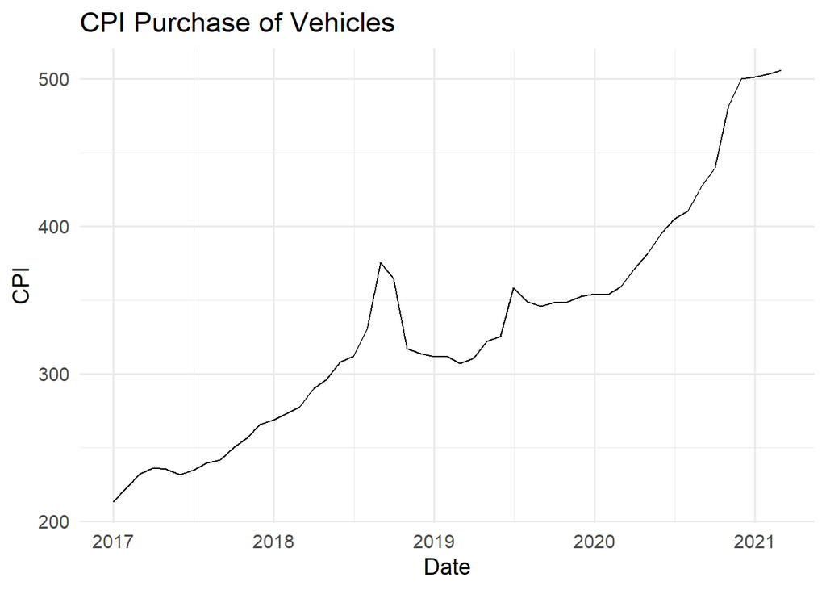

```r
ggplot(data=df, aes(x=Date, y=cpi_vehicles)) + geom_line()+labs(y="CPI", x="Date", title="CPI Purchase of Vehicles") + theme_minimal(base_size=14)
```

Series show clear upward trend.Between summer of 2018 and summer of 2019 CPI values are not following the general trend. There are two peaks, one in fall 2018 and one in summer 2019. During this short periods CPI values deviate from its normal behaviour with steep increases that are followed immediately by steep decreases. Another abnormality is in the fall 2020 when increase of CPI is steeper. This increase is followed by a still period which continues.

Total car production over 4 years looks like this

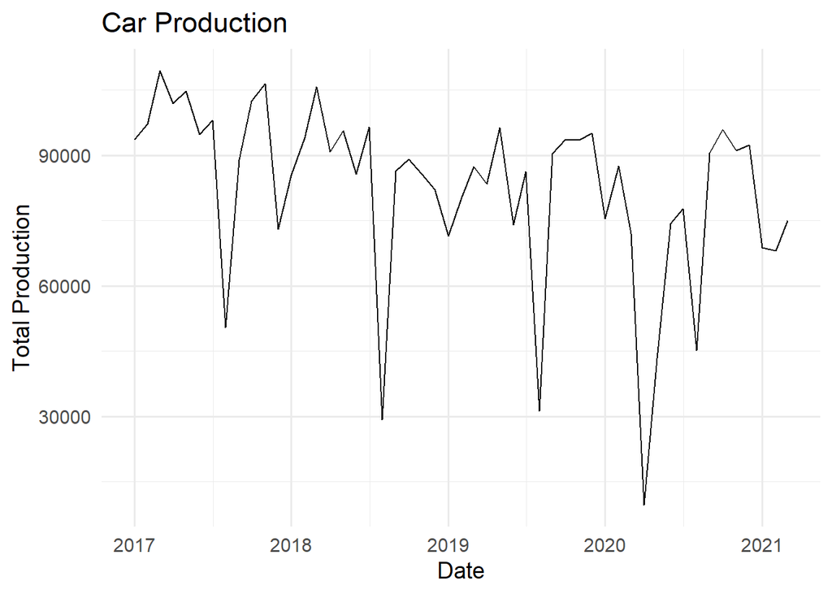

```r
ggplot(data=df, aes(x=Date, y=car_production)) + geom_line()+labs(y="Total Production", x="Date", title="Car Production")+ theme_minimal(base_size=14)
```

There is not any trend in car production series. Most remarkable behaviour is spikes that means low production around July. This low production intervals could be due to summer holidays when automobile factories are closed and workers are in vacation. In March of 2020 there is a decline in production due to disruption caused by COVID-19 pandemic.

In order to observe gold prices I preferred to use Cumhuriyet gold prices series which looks like this

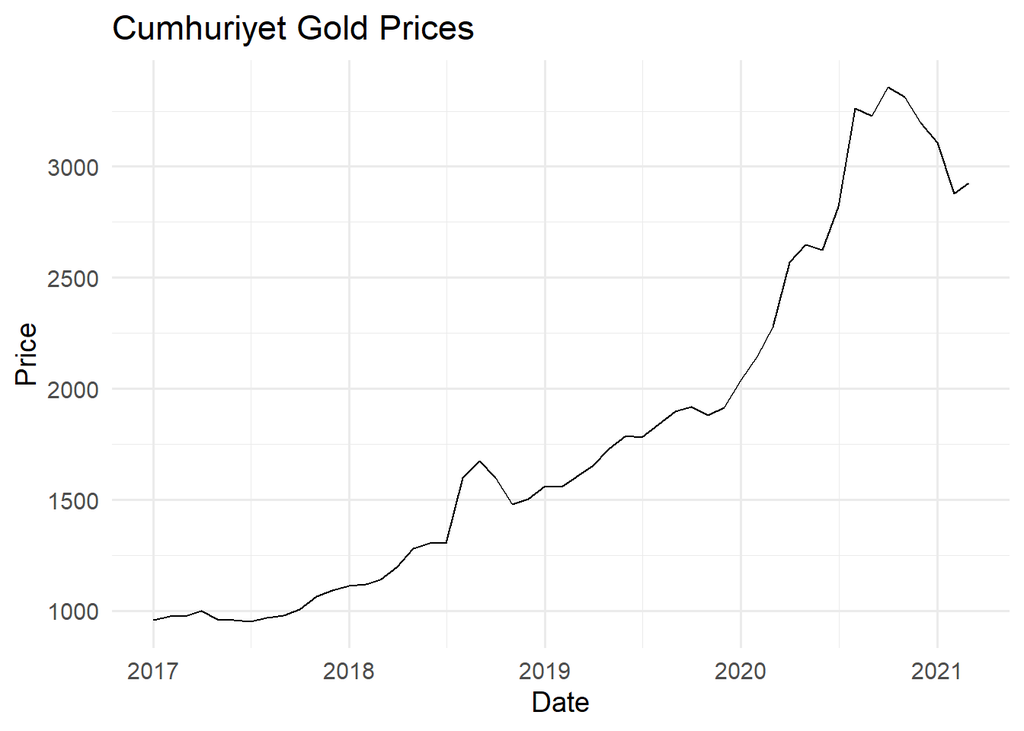

```r
ggplot(data=df, aes(x=Date, y=gold_price)) + geom_line()+labs(y="Price", x="Date", title="Cumhuriyet Gold Prices")+ theme_minimal(base_size=14)
```

Gold prices show upward trend.In summer 2018 there is a peak. Starting from the beginning of 2020 increase in gold prices gets steeper. Unlike usual upward trend there is a decline starting from fall of 2020.

I used weighted average interest rates for total deposits in TL.

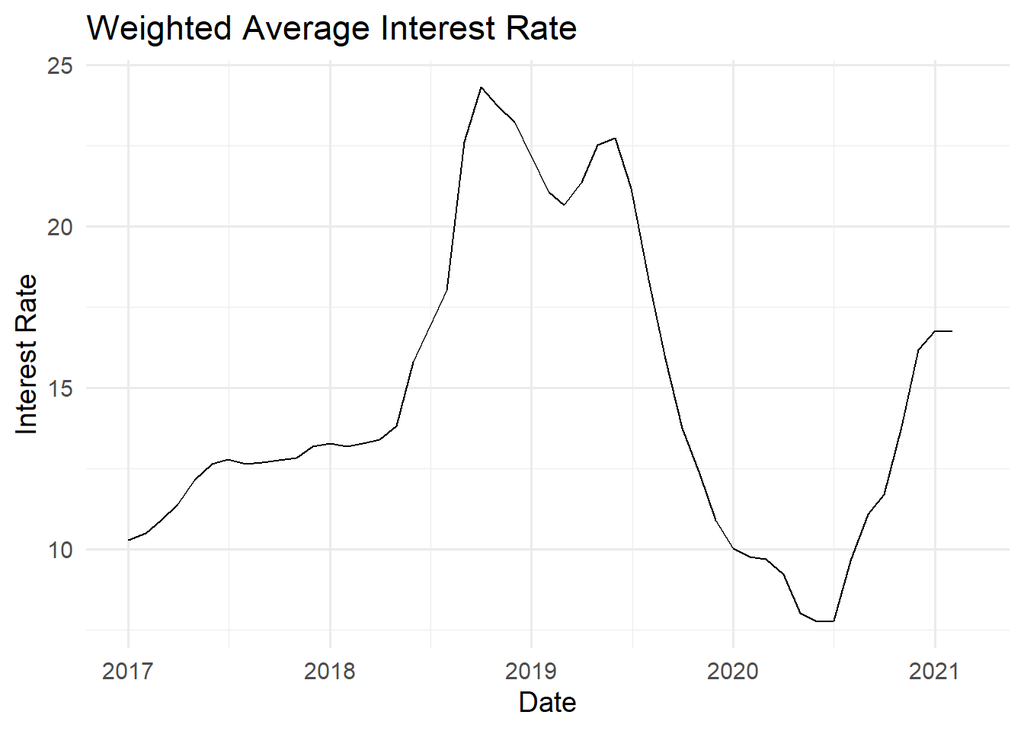

```r
ggplot(data=df, aes(x=Date, y=avg_interest_rate)) + geom_line()+labs(y="Interest Rate", x="Date", title="Weighted Average Interest Rate")+ theme_minimal(base_size=14)
```

Interest rate neither have a trend nor a seasonal behavior.

CPI based real effective exchange rate is used to account for exchange rate and it looks like this

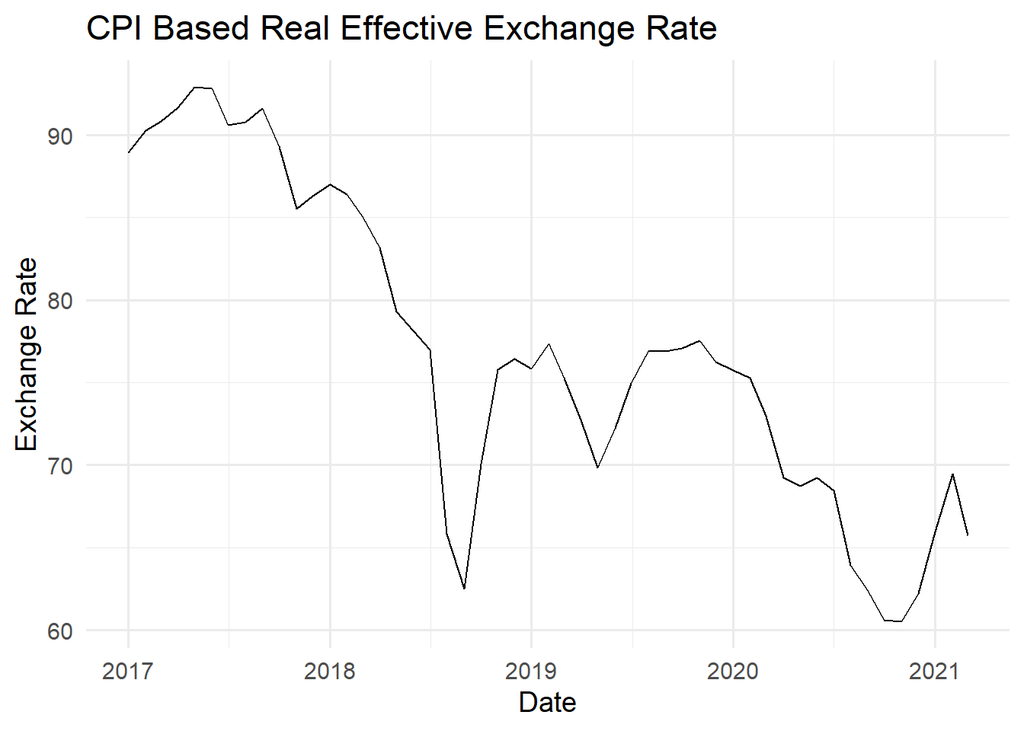

```r
ggplot(data=df, aes(x=Date, y=exchange_rate)) + geom_line()+labs(y="Exchange Rate", x="Date", title="CPI Based Real Effective Exchange Rate")+ theme_minimal(base_size=14)
```

Exchange rate has a downward trend. Any seasonal change is not observed. There are several steep declines and increases but there is not any similarity between them.

## Search Data

For further analysis I used search volumes of phrase “satılık araba” in Google. Using Google Trends I downloaded search volume data for 5 years. Since other series start from 2017 I discarded data of 2016. Then, I aggregate search volumes to a monthly level.

I merged previous dataframe with search volumes data and normalized values in order to get meaningful visualizations.

```r
search_data = read.csv("multiTimeline.csv")
search_data = data.frame(search_data)
search_data <- rename(search_data, search=satilik.araba...Türkiye. , Date = Hafta)
search_data$Date <- as.Date(search_data$Date , format = "%Y-%m-%d")
search_data$Date <- floor_date(search_data$Date, "month")
search_data <- search_data%>%group_by(Date)%>%summarize(sum = sum(search))
search_data <- search_data[search_data$Date>="2017-01-01" & search_data$Date<="2021-01-01",]

cpi_search<- merge(search_data,df, by="Date")
cpi_search <- cpi_search %>% mutate(
  cpi_vehicles = ((cpi_vehicles-min(cpi_vehicles,na.rm=TRUE))/(max(cpi_vehicles,na.rm=TRUE)-min(cpi_vehicles,na.rm=TRUE))),
  sum = ((sum-min(sum,na.rm=TRUE))/(max(sum,na.rm=TRUE)-min(sum,na.rm=TRUE))),
  avg_interest_rate = ((avg_interest_rate-min(avg_interest_rate,na.rm=TRUE))/(max(avg_interest_rate,na.rm=TRUE)-min(avg_interest_rate,na.rm=TRUE))),
  exchange_rate = ((exchange_rate-min(exchange_rate,na.rm=TRUE))/(max(exchange_rate,na.rm=TRUE)-min(exchange_rate,na.rm=TRUE))),
  gold_price = ((gold_price-min(gold_price,na.rm=TRUE))/(max(gold_price,na.rm=TRUE)-min(gold_price,na.rm=TRUE))),
  car_production = ((car_production-min(car_production,na.rm=TRUE))/(max(car_production,na.rm=TRUE)-min(car_production,na.rm=TRUE))))
```

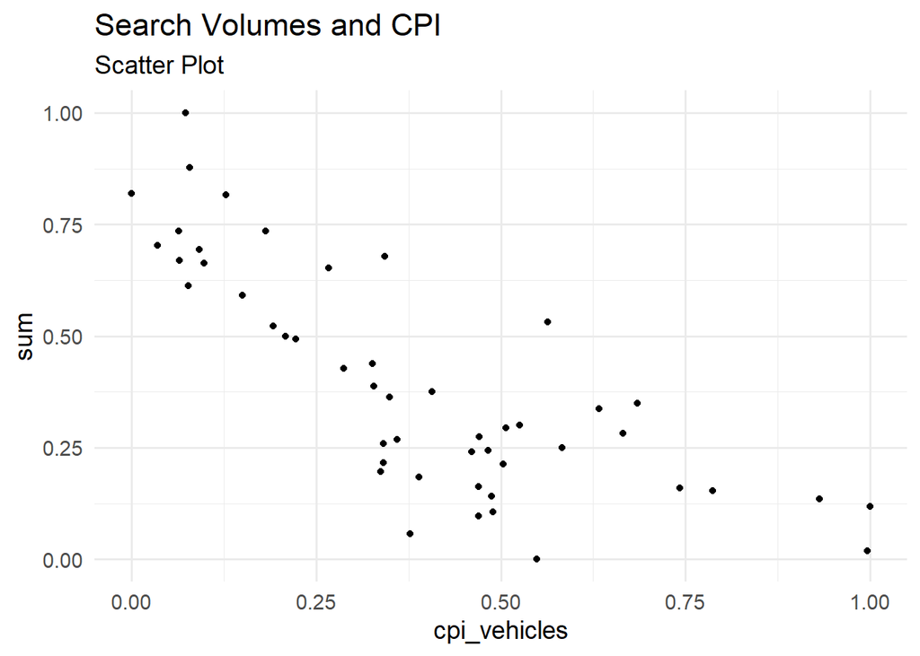

```r
ggplot(data=cpi_search, aes(x=cpi_vehicles, y=sum))+geom_point()+labs(xlab="CPI", ylab="Search Volume", title="Search Volumes and CPI", subtitle = "Scatter Plot")+theme_minimal(base_size=14)
```

From the scatter plot linear relationship between CPI and search volumes could be observed. There is negative linear relationship.

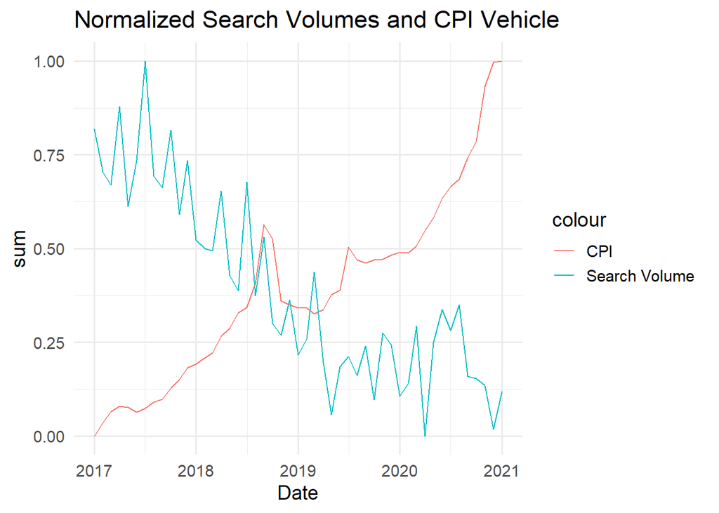

```r
ggplot(data=cpi_search, aes(x=Date, y=sum, color="Search Volume "))+geom_line()+geom_line(aes(y=cpi_vehicles,color="CPI"))+labs(xlab="Values", ylab="Date", title="Normalized Search Volumes and CPI Vehicle")+theme_minimal(base_size=14)
```

Line plot supports observations from scatter plot. While CPI value shows increasing trend, search volumes show decreasing behaviour.

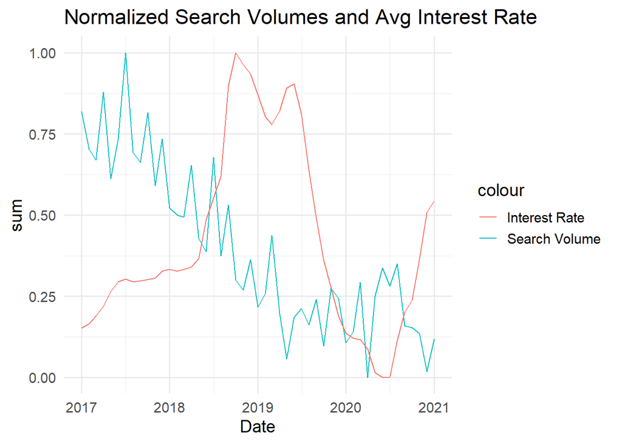

```r
ggplot(data=cpi_search, aes(x=Date, y=sum, color="Search Volume "))+geom_line()+geom_line(aes(y=avg_interest_rate,color="Interest Rate"))+labs(xlab="Values", ylab="Date", title="Normalized Search Volumes and Avg Interest Rate")+theme_minimal(base_size=14)
```

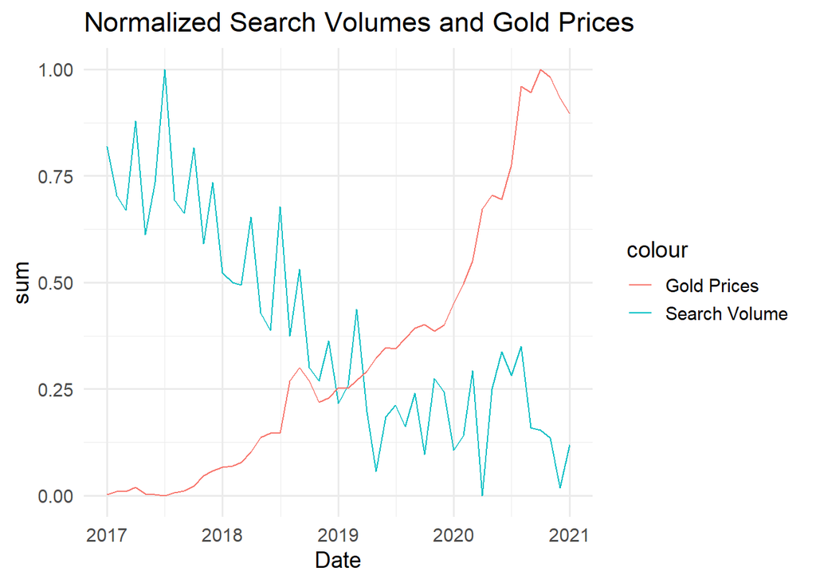

```r
ggplot(data=cpi_search, aes(x=Date, y=sum, color="Search Volume "))+geom_line()+geom_line(aes(y=gold_price,color="Gold Prices"))+labs(xlab="Values", ylab="Date", title="Normalized Search Volumes and Gold Prices")+theme_minimal(base_size=14)
```

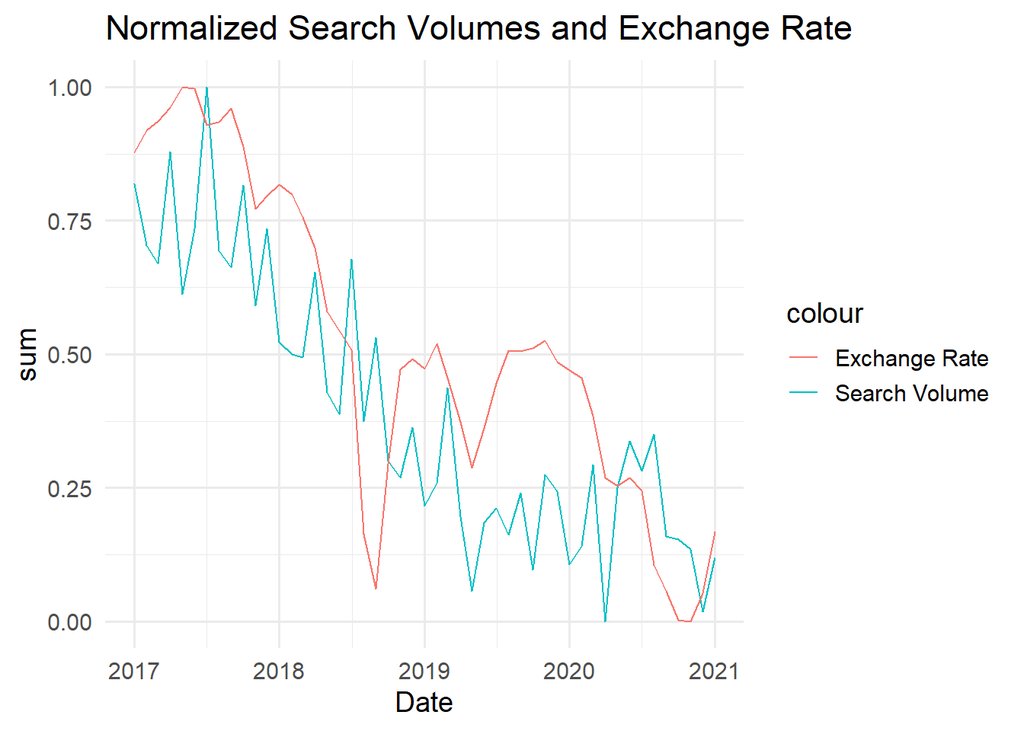

```r
ggplot(data=cpi_search, aes(x=Date, y=sum, color="Search Volume "))+geom_line()+geom_line(aes(y=exchange_rate,color="Exchange Rate"))+labs(xlab="Values", ylab="Date", title="Normalized Search Volumes and Exchange Rate")+theme_minimal(base_size=14)
```

Both exchange rate and search volumes show decreasing trend over 4 years.

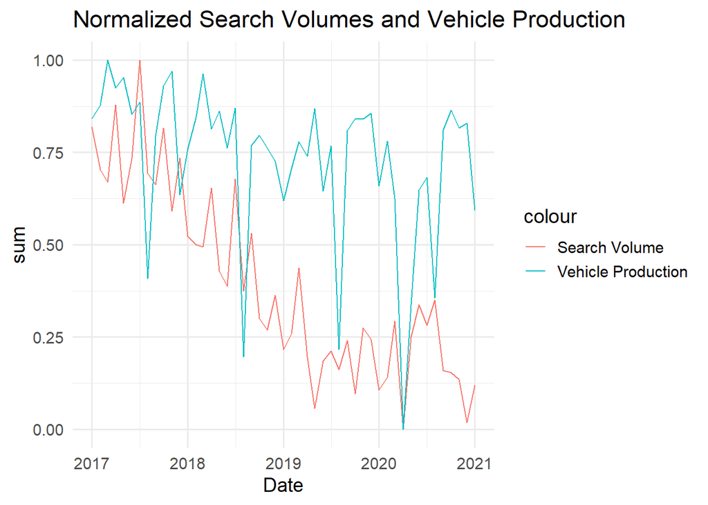

```r
ggplot(data=cpi_search, aes(x=Date, y=sum, color="Search Volume "))+geom_line()+geom_line(aes(y=car_production,color="Vehicle Production"))+labs(xlab="Values", ylab="Date", title="Normalized Search Volumes and Vehicle Production")+theme_minimal(base_size=14)
```